Laboratory Assignment 3.1

# Introduction

In this laboratory, we will cover the basic element of programming using a map-reduce methodology. For that purpose, we will be using Apache Spark as a reference, but bear in mind that similar frameworks exists and principles can be extrapolated.

## Some concepts and facts

- Spark is a distributed computing platform that operates on a cluster. Like MPI, we expect that nodes does NOT share a memory space but they are connected in high-speed dedicated network. Distributed filesystems that work over the network are extremely useful.
- It is considered the next generation of previous map-reduce standard Apache Hadoop. Main difference is thought to be the use of the memory instead of disk for intermediate operations, but there are many more improvements.
- It is built on Java. Despite this, it can be programmed using Java, Scala, Python or R. The complete API can only be found in JVM-based languages but the most frequent one is PySpark, since people is reluctant to use JVM-based languages in data science. Indeed, since Hadoop was only available for Java, it is likely that some Java codes of Spark are adaptations of previous Hadoop codes.
- Resilient Distributed Dataset (RDD): the basic unit that is processed in Spark. Equivalent to a numpy array but distributed.
- RDD API usually exposes the low-level operations of Apache Spark, useful for preprocessing data but useless for data analytics
- For data analysis, Dataframe and Spark SQL is used. It relies on a pandas-alike API that even accepts SQL code (which may sound crazy and useless for developers, but many *old* data scientists and statisticians are really proficient in SQL but not in Python).

## How to install Spark in colab.

```python
spark_version = "3.5.3"
hadoop_version = "3"
!apt-get update
!apt-get install openjdk-8-jdk-headless -qq # Install JVM v8
!wget -O spark-{spark_version}-bin-hadoop{hadoop_version}.tgz -q https://downloads.apache.org/spark/spark-{spark_version}/spark-{spark_version}-bin-hadoop{hadoop_version}.tgz # Download latest release. Update if necessary
!tar xf spark-{spark_version}-bin-hadoop{hadoop_version}.tgz # Unzip
!pip install pyspark # Well, the library itself
import os
os.environ["JAVA_HOME"] = "/usr/lib/jvm/java-8-openjdk-amd64"
os.environ["SPARK_HOME"] = f"/content/spark-{spark_version}-bin-hadoop{hadoop_version}"
```

[output not shown]

## How to initialize Spark

```python
from pyspark.sql import SparkSession

APP_NAME = "CAP-lab3"
SPARK_URL = "local[*]"
spark = SparkSession.builder.appName(APP_NAME).master(SPARK_URL).getOrCreate()
sc = spark.sparkContext
```

# First Part: RDDs

## Basic operations

### Parallelize & collect

It creates a RDD out of a list or array. Second argument indicates the number of pieces of the RDD

```python
array = sc.parallelize([1,2,3,4,5,6,7,8,9,10], 2)
array
```

```
ParallelCollectionRDD[0] at readRDDFromFile at PythonRDD.scala:289
```

```python
import numpy as np
randomSamples = sc.parallelize(np.random.randn(100))
randomSamples
```

```
ParallelCollectionRDD[1] at readRDDFromFile at PythonRDD.scala:289
```

Cool, RDDs can not be printed...

Of course, RDDs can not be printed unless they are reduced

```python
print(array.collect())
print(randomSamples.collect())
```

```
[1, 2, 3, 4, 5, 6, 7, 8, 9, 10]
[-3.1049025460771342, 0.039693573409463674, -0.32217796306401025, 0.9494938601646784, 0.6199267329030829, -0.5353042361777789, -0.8078790855866422, 1.0213056154771318, -0.18904538186482528, 0.16295818170162987, -0.23399167941913482, -0.382405587950365, 0.7290573513110571, 0.36076095423401217, -0.070…
```

Spark uses lazy operations for everything, this means that nothing is evaluated until an action, a reduce operation normally, is performed. The basic reduce operation is collect, which returns the whole RDD (i.e. no reduction is performed).

### Other ways of loading data

```python
import requests

request = requests.get("https://gist.githubusercontent.com/jsdario/6d6c69398cb0c73111e49f1218960f79/raw/8d4fc4548d437e2a7203a5aeeace5477f598827d/el_quijote.txt")
with open("elquijote.txt", "wb") as f:
  f.write(request.content)
```

```python
quijote = sc.textFile("elquijote.txt")
quijote.take(10)
```

```
['DON QUIJOTE DE LA MANCHA',
 'Miguel de Cervantes Saavedra',
 '',
 'PRIMERA PARTE',
 'CAPÍTULO 1: Que trata de la condición y ejercicio del famoso hidalgo D. Quijote de la Mancha',
 'En un lugar de la Mancha, de cuyo nombre no quiero acordarme, no ha mucho tiempo que vivía un hidalgo de los de lanza en astillero, adarga antigua, rocín flaco y galgo corredor. Una olla de algo más vaca que carnero, salpicón las más noches, duelos y quebrantos los sábados, lentejas los viernes, a…
 'Tuvo muchas veces competencia con el cura de su lugar (que era hombre docto graduado en Sigüenza), sobre cuál había sido mejor caballero, Palmerín de Inglaterra o Amadís de Gaula; mas maese Nicolás, barbero del mismo pueblo, decía que ninguno llegaba al caballero del Febo, y que si alguno se le po…
 'En resolución, él se enfrascó tanto en su lectura, que se le pasaban las noches leyendo de claro en claro, y los días de turbio en turbio, y así, del poco dormir y del mucho leer, se le secó el cerebro, de manera que vino a perder el juicio. Llenósele la fantasía de todo aquello que leía en los li…
 'historia más cierta en el mundo.',
 'Decía él, que el Cid Ruy Díaz había sido muy buen caballero; pero que no tenía que ver con el caballero de la ardiente espada, que de sólo un revés había partido por medio dos fieros y descomunales gigantes. Mejor estaba con Bernardo del Carpio, porque en Roncesvalle había muerto a Roldán el encan…
```

Here, you can see both a method to load a text file line per line and a another reduction operation.

```python
quijote.take?
```

```
Object `quijote.take` not found.
```

### Transformations

Let's review all the transformation that can be performed to data.

```python
charsPerLine = quijote.map(lambda s: len(s))
allWords = quijote.flatMap(lambda s: s.split())
allWordsNoArticles = allWords.filter(lambda a: a.lower() not in ["el", "la"])
allWordsUnique = allWords.map(lambda s: s.lower()).distinct()
sampleWords = allWords.sample(withReplacement=True, fraction=0.2, seed=666)
weirdSampling = sampleWords.union(allWordsNoArticles.sample(False, fraction=0.3))
```

```python
allWordsUnique.take(10)
```

```
['don',
 'mancha',
 'saavedra',
 'primera',
 'parte',
 '1:',
 'que',
 'condición',
 'y',
 'del']
```

Assignment question

Explain the use and purpose of each operation above.

Comment also on the size of the resulting RDD in terms of the size of the original RDD, e.g. if original RDD is of size $N$, then rdd.filter() is of size $K\leq N$

Answer:

- map: Aplica una función a cada elemento del RDD y devuelve el nuevo RDD. El tamaño de RDD es de $N$.
- flatMap: Aplica una función a cada elemento del RDD y aplana los resultados. El tamaño del RDD depende de la cantidad de elementos generados por la función.
- filter: Filtra los elementos del RDD según la condición especificada, devolviendo un RDD nuevo con los elementos filtrados. Tamaño del RDD es $K\leq N$.
- distinct: Elimina los elementos duplicados del RDD y devuelve un nuevo RDD sin elementos duplicados. Tamaño del RDD $K\leq N$.
- sample: Extrae una muestra de los elementos RDD según la fracción. Tamaño de RDD es $K\leq N$.
- union: Unifica los datos del RDD original con los del nuevo RDD, incluye duplicados. Tamaño del RDD es $N1$ + $N2$.

### Actions

```python
numLines = quijote.count()
numChars = charsPerLine.reduce(lambda a,b: a+b) # also charsPerLine.sum()
sortedWordsByLength = allWordsNoArticles.takeOrdered(10, key=lambda x: -len(x))
numLines, numChars, sortedWordsByLength
```

```
(2186,
 1036211,
 ['procuremos.Levántate,',
  'extraordinariamente,',
  'estrechísimamente,',
  'convirtiéndoseles',
  'entretenimientos,',
  'inadvertidamente.',
  'cortesísimamente',
  'Agredeciéronselo',
  'Pintiquiniestra,',
  'entretenimiento,'])
```

Assignment question

Explain the use and purpose of each action above.

Implement the count operation using reduce as the unique option. You can use transformations. Is it possible to achieve a solution without any transformation? Does it make sense?

Answer:

```python
numLines = quijote.map(lambda s: 1)
numLines = numLines.reduce(lambda a,b: a+b)
numLines
```

```
2186
```

No es posible hacerlo sin niguna transformación por que se realizan acciones sobre transformaciones ya hechas anteriormente.

## Key-Value RDDs

```python
import re
allWords = allWords.flatMap(lambda w: re.sub(""";|:|\.|,|-|–|"|'|\s"""," ", w.lower()).split(" ")).filter(lambda a: len(a)>0)
allWords2 = sc.parallelize(requests.get("https://gist.githubusercontent.com/jsdario/9d871ed773c81bf217f57d1db2d2503f/raw/585de69b0631c805dabc6280506717943b82ba4a/el_quijote_ii.txt").iter_lines())
allWords2 = allWords2.flatMap(lambda w: re.sub(""";|:|\.|,|-|–|"|'|\s"""," ", w.decode("utf8").lower()).split(" ")).filter(lambda a: len(a)>0)
```

```python
allWords.take(10), allWords2.take(10)
```

```
(['don',
  'quijote',
  'de',
  'la',
  'mancha',
  'miguel',
  'de',
  'cervantes',
  'saavedra',
  'primera'],
 ['don',
  'quijote',
  'de',
  'la',
  'mancha',
  'miguel',
  'de',
  'cervantes',
  'saavedra',
  'segunda'])
```

Next, we move to more interesting operations that involve key-value RDDs. Key-value RDDs are a special kind of RDDs where each is element is a tuple (K,V) where K is the key and V the value.

```python
words = allWords.map(lambda e: (e,1))
words2 = allWords2.map(lambda e: (e,1))

words.take(10)
```

```
[('don', 1),
 ('quijote', 1),
 ('de', 1),
 ('la', 1),
 ('mancha', 1),
 ('miguel', 1),
 ('de', 1),
 ('cervantes', 1),
 ('saavedra', 1),
 ('primera', 1)]
```

```python
words2.take(10)
```

```
[('don', 1),
 ('quijote', 1),
 ('de', 1),
 ('la', 1),
 ('mancha', 1),
 ('miguel', 1),
 ('de', 1),
 ('cervantes', 1),
 ('saavedra', 1),
 ('segunda', 1)]
```

### How to manipulate K-V RDDs

```python
frequencies = words.reduceByKey(lambda a,b: a+b)
frequencies2 = words2.reduceByKey(lambda a,b: a+b)
frequencies.takeOrdered(10, key=lambda a: -a[1])
```

```
[('que', 10705),
 ('de', 9033),
 ('y', 8668),
 ('la', 5015),
 ('a', 4815),
 ('en', 4046),
 ('el', 3857),
 ('no', 3083),
 ('se', 2382),
 ('los', 2148)]
```

```python
res = words.groupByKey().takeOrdered(10, key=lambda a: -len(a))
res # To see the content, res[i][1].data
```

```
[('don', <pyspark.resultiterable.ResultIterable at 0x78c431095150>),
 ('mancha', <pyspark.resultiterable.ResultIterable at 0x78c4310962c0>),
 ('saavedra', <pyspark.resultiterable.ResultIterable at 0x78c4310962f0>),
 ('primera', <pyspark.resultiterable.ResultIterable at 0x78c431096470>),
 ('parte', <pyspark.resultiterable.ResultIterable at 0x78c431096440>),
 ('1', <pyspark.resultiterable.ResultIterable at 0x78c4310964a0>),
 ('que', <pyspark.resultiterable.ResultIterable at 0x78c431096530>),
 ('condición', <pyspark.resultiterable.ResultIterable at 0x78c431096590>),
 ('y', <pyspark.resultiterable.ResultIterable at 0x78c4310965f0>),
 ('del', <pyspark.resultiterable.ResultIterable at 0x78c431096650>)]
```

```python
joinFreq = frequencies.join(frequencies2)
joinFreq.take(10)
```

```
[('don', (1072, 1606)),
 ('mancha', (50, 101)),
 ('saavedra', (2, 1)),
 ('primera', (39, 55)),
 ('parte', (178, 158)),
 ('1', (1, 1)),
 ('que', (10705, 10040)),
 ('condición', (33, 39)),
 ('y', (8668, 9650)),
 ('del', (1128, 1344))]
```

```python
joinFreq.map(lambda e: (e[0], (e[1][0] - e[1][1])/(e[1][0] + e[1][1]))).takeOrdered(10, lambda v: -v[1]), joinFreq.map(lambda e: (e[0], (e[1][0] - e[1][1])/(e[1][0] + e[1][1]))).takeOrdered(10, lambda v: +v[1])
```

```
([('bacía', 0.9393939393939394),
  ('venia', 0.9230769230769231),
  ('hermandad', 0.9),
  ('andrés', 0.8823529411764706),
  ('peña', 0.8823529411764706),
  ('micomicona', 0.8823529411764706),
  ('barca', 0.875),
  ('novela', 0.875),
  ('yerme', 0.875),
  ('acertó', 0.8666666666666667)],
 [('teresa', -0.9767441860465116),
  ('roque', -0.96),
  ('refranes', -0.9375),
  ('condesa', -0.9333333333333333),
  ('leones', -0.9333333333333333),
  ('gobernadores', -0.9166666666666666),
  ('lacayo', -0.9166666666666666),
  ('visorrey', -0.9130434782608695),
  ('antonio', -0.9076923076923077),
  ('zaragoza', -0.9047619047619048)])
```

Assignment question

Explain the use and purpose of each action above.

Implement the frequency with groupByKey and transformations.

Which of the two following cells is more efficient?

Answer:

- reduceByKey: agrupa los valores por clave y los reduce.
- groupByKey: agrupa todos los elementos de una misma clave y los mete en una lista
- takeOrdered: devuelve los primeros N elementos de un RDD
- join: combina dos RDDs en base a las claves que comparten, generando pares de valores con claves comunes.

```python
frequency3 = words.groupByKey()
frequency3.take(10)
```

```
[('don', <pyspark.resultiterable.ResultIterable at 0x78c431096c80>),
 ('mancha', <pyspark.resultiterable.ResultIterable at 0x78c431097c40>),
 ('saavedra', <pyspark.resultiterable.ResultIterable at 0x78c431096140>),
 ('primera', <pyspark.resultiterable.ResultIterable at 0x78c431097af0>),
 ('parte', <pyspark.resultiterable.ResultIterable at 0x78c431097580>),
 ('1', <pyspark.resultiterable.ResultIterable at 0x78c4310971f0>),
 ('que', <pyspark.resultiterable.ResultIterable at 0x78c4310969b0>),
 ('condición', <pyspark.resultiterable.ResultIterable at 0x78c431097a00>),
 ('y', <pyspark.resultiterable.ResultIterable at 0x78c4310958d0>),
 ('del', <pyspark.resultiterable.ResultIterable at 0x78c4310971c0>)]
```

La segunda celda es más eficiente, ya que hace los cálculos una sola vez y luego la ordena y muestra los valores que solicita, mientras que en la primera celda, hace 2 veces el mapeo.

```python
joinFreq.map(lambda e: (e[0], (e[1][0] - e[1][1])/(e[1][0] + e[1][1]))).takeOrdered(10, lambda v: -v[1]), joinFreq.map(lambda e: (e[0], (e[1][0] - e[1][1])/(e[1][0] + e[1][1]))).takeOrdered(10, lambda v: +v[1])
```

```
([('bacía', 0.9393939393939394),
  ('venia', 0.9230769230769231),
  ('hermandad', 0.9),
  ('andrés', 0.8823529411764706),
  ('peña', 0.8823529411764706),
  ('micomicona', 0.8823529411764706),
  ('barca', 0.875),
  ('novela', 0.875),
  ('yerme', 0.875),
  ('acertó', 0.8666666666666667)],
 [('teresa', -0.9767441860465116),
  ('roque', -0.96),
  ('refranes', -0.9375),
  ('condesa', -0.9333333333333333),
  ('leones', -0.9333333333333333),
  ('gobernadores', -0.9166666666666666),
  ('lacayo', -0.9166666666666666),
  ('visorrey', -0.9130434782608695),
  ('antonio', -0.9076923076923077),
  ('zaragoza', -0.9047619047619048)])
```

```python
result = joinFreq.map(lambda e: (e[0], (e[1][0] - e[1][1])/(e[1][0] + e[1][1])))
result.takeOrdered(10, lambda v: -v[1]), result.takeOrdered(10, lambda v: +v[1])
```

```
([('bacía', 0.9393939393939394),
  ('venia', 0.9230769230769231),
  ('hermandad', 0.9),
  ('andrés', 0.8823529411764706),
  ('peña', 0.8823529411764706),
  ('micomicona', 0.8823529411764706),
  ('barca', 0.875),
  ('novela', 0.875),
  ('yerme', 0.875),
  ('acertó', 0.8666666666666667)],
 [('teresa', -0.9767441860465116),
  ('roque', -0.96),
  ('refranes', -0.9375),
  ('condesa', -0.9333333333333333),
  ('leones', -0.9333333333333333),
  ('gobernadores', -0.9166666666666666),
  ('lacayo', -0.9166666666666666),
  ('visorrey', -0.9130434782608695),
  ('antonio', -0.9076923076923077),
  ('zaragoza', -0.9047619047619048)])
```

## Optimizations and final notes

### Optimizing the data movement around the cluster

One of the main issues could be that if data after an operation is not balanced, we may not be using the cluster properly. For that purpose, we have two operations

```python
result.coalesce(numPartitions=2) # Avoids the data movement, so it tries to balance inside each machine
result.repartition(numPartitions=2) # We don't care about data movement, this balance the whole thing to ensure all machines are used
```

```
MapPartitionsRDD[57] at coalesce at NativeMethodAccessorImpl.java:0
```

### Persistance for intermediate operations

In contrast to Hadoop, intermediate RDDs are not preserved, each time we use an action/reduction, the whole data pipeline is executed from the datasources. To avoid this:

```python
result.take(10)
allWords.cache() # allWords RDD must  stay in memory after computation, we made a checkpoint (well, it's a best effort, so must might be too strong)
result.take(10)
```

```
[('don', -0.19940253920836445),
 ('mancha', -0.33774834437086093),
 ('saavedra', 0.3333333333333333),
 ('primera', -0.1702127659574468),
 ('parte', 0.05952380952380952),
 ('1', 0.0),
 ('que', 0.03205591708845505),
 ('condición', -0.08333333333333333),
 ('y', -0.05360847254067038),
 ('del', -0.08737864077669903)]
```

```python
from pyspark import StorageLevel
# https://spark.apache.org/docs/2.2.0/rdd-programming-guide.html#rdd-persistence
allWords2.persist(StorageLevel.MEMORY_AND_DISK) # Now it will be preserved on disk also
```

```
PythonRDD[61] at RDD at PythonRDD.scala:53
```

```python
!rm -rf palabras_parte2
allWords2.saveAsTextFile("palabras_parte2")
```

```python
!ls palabras_parte2
```

```
part-00000  part-00001	_SUCCESS
```

Assignment question

Before saving with saveAsTextFile, use coalesce with different values. What's the difference in the previous ls?

Answer:

Al ir probando distintos valores para las particiones vemos que el resultado al ejecutar !ls plabras_parte2 es el mismo. Siempre sale part-00000 part-00001 _SUCCESS.

### Global variables

There are two kind of global variables, read-only and write-only.

```python
articles = sc.broadcast(["el", "la"])
articles.value
```

```
['el', 'la']
```

Broadcast variables are read-only. They help us to avoid local variables of the closures (the functions we use inside map, reduce, ...) to be transferred in every single Spark operation. In that way, they are only transferred only once.

```python
acc = sc.accumulator(0)
def incrementar(x):
  global acc
  acc += x

allWords.map(lambda l:1).foreach(incrementar)
acc
```

```
Accumulator<id=0, value=187045>
```

Write-only variables can be also declared and initialized, but they can not be read since reading will force a complete synchronization of the cluster.

# Second part: Spark SQL

Next, we will do a short review of the high-level API of Spark

```python
import pandas as pd

size = int(1e6)
def loadRedditToPandas(subreddit=None, size=size):
  if subreddit is not None:
    redditData = requests.get(f"https://api.pushshift.io/reddit/search/submission/?subreddit={subreddit}&sort=desc&sort_type=created_utc&size={size:d}").json()
  else:
    redditData = requests.get(f"https://api.pushshift.io/reddit/search/submission/?sort=desc&sort_type=created_utc&size={size:d}").json()
  print(redditData)
  return pd.DataFrame(redditData["data"])
!wget -O RS_2016_02_reduced http://mirai.ii.uam.es/RS_2016_02_reduced
```

```
--2024-11-14 18:32:33--  http://mirai.ii.uam.es/RS_2016_02_reduced
Resolving mirai.ii.uam.es (mirai.ii.uam.es)... 150.244.59.231
Connecting to mirai.ii.uam.es (mirai.ii.uam.es)|150.244.59.231|:80... connected.
HTTP request sent, awaiting response... 200 OK
Length: 365538337 (349M) [application/octet-stream]
Saving to: ‘RS_2016_02_reduced’

RS_2016_02_reduced  100%[===================>] 348.60M  30.4MB/s    in 12s

2024-11-14 18:32:45 (28.6 MB/s) - ‘RS_2016_02_reduced’ saved [365538337/365538337]
```

```python
#pdf = loadRedditToPandas() #Debido a los cambios en el API de reddit, ya no se pueden extraer datos sin hacer login
import json
import pandas as pd
def load():
  with open("RS_2016_02_reduced", "r") as f:
    for line in f:
      post = json.loads(line)
      yield post
pdf = pd.DataFrame(load())
pdf.head()
```

|  | from | created_utc | saved | num_comments | permalink | from_id | domain | id | url | stickied | ... | preview | adserver_click_url | third_party_tracking | mobile_ad_url | imp_pixel | promoted | disable_comments | href_url | adserver_imp_pixel | third_party_tracking_2 |
| --- | --- | --- | --- | --- | --- | --- | --- | --- | --- | --- | --- | --- | --- | --- | --- | --- | --- | --- | --- | --- | --- |
| 0 | NaN | 1454284800 | False | 0 | /r/Gear4Sale/comments/43lprb/wts_tech21_sansam... | NaN | self.Gear4Sale | 43lprb | https://www.reddit.com/r/Gear4Sale/comments/43... | False | ... | NaN | NaN | NaN | NaN | NaN | NaN | NaN | NaN | NaN | NaN |
| 1 | NaN | 1454284800 | False | 1 | /r/ImagesOfIllinois/comments/43lprc/fsft_mayac... | NaN | imgur.com | 43lprc | http://imgur.com/RpmdaVK | False | ... | {'images': [{'variants': {}, 'resolutions': [{... | NaN | NaN | NaN | NaN | NaN | NaN | NaN | NaN | NaN |
| 2 | NaN | 1454284800 | False | 4 | /r/customhearthstone/comments/43lprd/a_combina... | NaN | i.imgur.com | 43lprd | http://i.imgur.com/AOmpm4b.png | False | ... | {'images': [{'source': {'url': 'https://i.redd... | NaN | NaN | NaN | NaN | NaN | NaN | NaN | NaN | NaN |
| 3 | NaN | 1454284801 | False | 3 | /r/Fireteams/comments/43lpre/ps4_lf2m_too_flaw... | NaN | self.Fireteams | 43lpre | https://www.reddit.com/r/Fireteams/comments/43... | False | ... | NaN | NaN | NaN | NaN | NaN | NaN | NaN | NaN | NaN | NaN |
| 4 | NaN | 1454284801 | False | 2 | /r/recordthis/comments/43lprg/feedback_the_sou... | NaN | self.recordthis | 43lprg | https://www.reddit.com/r/recordthis/comments/4... | False | ... | NaN | NaN | NaN | NaN | NaN | NaN | NaN | NaN | NaN | NaN |

5 rows × 50 columns

```python
attrs = ["author", "created_utc", "title", "subreddit", "selftext", "over_18"]
pdf[attrs].head()
```

|  | author | created_utc | title | subreddit | selftext | over_18 |
| --- | --- | --- | --- | --- | --- | --- |
| 0 | [deleted] | 1454284800 | [WTS] Tech21 SansAmp Bass Driver - $175 Shipped | Gear4Sale | [deleted] | False |
| 1 | amici_ursi | 1454284800 | "[FS/FT] Mayaca, Crypt Wendtii, Java Fern, and... | ImagesOfIllinois |  | False |
| 2 | Buhadog | 1454284800 | A combination of Recombobulator and Polymorph | customhearthstone |  | False |
| 3 | DJOlYoungin | 1454284801 | [PS4] LF2M ToO Flawless. 1500+ elo | Fireteams | Leave psn and I'll add to party | False |
| 4 | BrightenQuintin | 1454284801 | [FEEDBACK] The Soulstealer Audition | recordthis | https://www.castingcall.club/auditions/95105\n... | False |

```python
df = spark.createDataFrame(pdf[attrs])
```

```python
#pdf.selftext = pdf.selftext.apply(lambda e: str(e))
```

```python
#df = spark.createDataFrame(pdf[attrs])
#df = spark.createDataFrame(df[attrs])
```

## Basic operations

```python
df.show()
```

```
+---------------+-----------+--------------------+-----------------+--------------------+-------+
|         author|created_utc|               title|        subreddit|            selftext|over_18|
+---------------+-----------+--------------------+-----------------+--------------------+-------+
|      [deleted]| 1454284800|[WTS] Tech21 Sans...|        Gear4Sale|           [deleted]|  false|
|     amici_ursi| 1454284800|"[FS/FT] Mayaca, ...| ImagesOfIllinois|                    |  false|
|        Buhadog| 1454284800|A combination of ...|customhearthstone|                    |  false|
|    DJOlYoungin| 1454284801|[PS4] LF2M ToO Fl...|        Fireteams|Leave psn and I'l...|  false|
|BrightenQuintin| 1454284801|[FEEDBACK] The So...|       recordthis|https://www.casti...|  false|
|         jptx82| 1454284802|The gloves bother...|mildlyinfuriating|                    |  false|
|       kahlil88| 1454284802|"questions" for m...|       Shoe0nHead|                    |  false|
|        OverSol| 1454284802|Visual Comparison...| BleachBraveSouls|After seeing the ...|  false|
|      [deleted]| 1454284802|hes tryin to turn...|        TheBarons|           [deleted]|  false|
|      [deleted]| 1454284802|If Charles Martel...|       metacanada|                    |  false|
|    Shadowwoods| 1454284802|      The Rocketship|         Noobtube|                    |  false|
|      [deleted]| 1454284802|Eat like your gra...|           canada|           [deleted]|  false|
|      [deleted]| 1454284802|[PS4] KF HM War p...|        Fireteams|           [deleted]|  false|
|       hxnterrr| 1454284802|I wish I could ca...|        blackops3|                    |  false|
| LoveGaugedGals| 1454284802|  wow what a phrame!|            ssbbw|                    |   true|
|      [deleted]| 1454284803|[Question] What i...|        jailbreak|           [deleted]|  false|
|MaconCountyLine| 1454284803|(Friendly Reminde...|         Sherlock|It will have been...|  false|
|      [deleted]| 1454284803|Kyber Crystals us...|         StarWars|Is there any cano...|  false|
|      [deleted]| 1454284804|DOWNLOAD BOOK "Wi...|  TekkitCreations|     Rebecca Jimenez|  false|
|       potzdamn| 1454284804|                Cruz|    FuckYeahWierd|                    |   true|
+---------------+-----------+--------------------+-----------------+--------------------+-------+
only showing top 20 rows
```

### Filtering

```python
df.filter(~df.over_18).show()
```

```
+---------------+-----------+--------------------+-----------------+--------------------+-------+
|         author|created_utc|               title|        subreddit|            selftext|over_18|
+---------------+-----------+--------------------+-----------------+--------------------+-------+
|      [deleted]| 1454284800|[WTS] Tech21 Sans...|        Gear4Sale|           [deleted]|  false|
|     amici_ursi| 1454284800|"[FS/FT] Mayaca, ...| ImagesOfIllinois|                    |  false|
|        Buhadog| 1454284800|A combination of ...|customhearthstone|                    |  false|
|    DJOlYoungin| 1454284801|[PS4] LF2M ToO Fl...|        Fireteams|Leave psn and I'l...|  false|
|BrightenQuintin| 1454284801|[FEEDBACK] The So...|       recordthis|https://www.casti...|  false|
|         jptx82| 1454284802|The gloves bother...|mildlyinfuriating|                    |  false|
|       kahlil88| 1454284802|"questions" for m...|       Shoe0nHead|                    |  false|
|        OverSol| 1454284802|Visual Comparison...| BleachBraveSouls|After seeing the ...|  false|
|      [deleted]| 1454284802|hes tryin to turn...|        TheBarons|           [deleted]|  false|
|      [deleted]| 1454284802|If Charles Martel...|       metacanada|                    |  false|
|    Shadowwoods| 1454284802|      The Rocketship|         Noobtube|                    |  false|
|      [deleted]| 1454284802|Eat like your gra...|           canada|           [deleted]|  false|
|      [deleted]| 1454284802|[PS4] KF HM War p...|        Fireteams|           [deleted]|  false|
|       hxnterrr| 1454284802|I wish I could ca...|        blackops3|                    |  false|
|      [deleted]| 1454284803|[Question] What i...|        jailbreak|           [deleted]|  false|
|MaconCountyLine| 1454284803|(Friendly Reminde...|         Sherlock|It will have been...|  false|
|      [deleted]| 1454284803|Kyber Crystals us...|         StarWars|Is there any cano...|  false|
|      [deleted]| 1454284804|DOWNLOAD BOOK "Wi...|  TekkitCreations|     Rebecca Jimenez|  false|
|           onrv| 1454284804|Foo Fighters - Fe...|   Musicthemetime|                    |  false|
|        ranalog| 1454284805|Monthly 'Self Pro...|           analog|This thread is fo...|  false|
+---------------+-----------+--------------------+-----------------+--------------------+-------+
only showing top 20 rows
```

```python
df.where(~df.over_18).show()
```

```
+---------------+-----------+--------------------+-----------------+--------------------+-------+
|         author|created_utc|               title|        subreddit|            selftext|over_18|
+---------------+-----------+--------------------+-----------------+--------------------+-------+
|      [deleted]| 1454284800|[WTS] Tech21 Sans...|        Gear4Sale|           [deleted]|  false|
|     amici_ursi| 1454284800|"[FS/FT] Mayaca, ...| ImagesOfIllinois|                    |  false|
|        Buhadog| 1454284800|A combination of ...|customhearthstone|                    |  false|
|    DJOlYoungin| 1454284801|[PS4] LF2M ToO Fl...|        Fireteams|Leave psn and I'l...|  false|
|BrightenQuintin| 1454284801|[FEEDBACK] The So...|       recordthis|https://www.casti...|  false|
|         jptx82| 1454284802|The gloves bother...|mildlyinfuriating|                    |  false|
|       kahlil88| 1454284802|"questions" for m...|       Shoe0nHead|                    |  false|
|        OverSol| 1454284802|Visual Comparison...| BleachBraveSouls|After seeing the ...|  false|
|      [deleted]| 1454284802|hes tryin to turn...|        TheBarons|           [deleted]|  false|
|      [deleted]| 1454284802|If Charles Martel...|       metacanada|                    |  false|
|    Shadowwoods| 1454284802|      The Rocketship|         Noobtube|                    |  false|
|      [deleted]| 1454284802|Eat like your gra...|           canada|           [deleted]|  false|
|      [deleted]| 1454284802|[PS4] KF HM War p...|        Fireteams|           [deleted]|  false|
|       hxnterrr| 1454284802|I wish I could ca...|        blackops3|                    |  false|
|      [deleted]| 1454284803|[Question] What i...|        jailbreak|           [deleted]|  false|
|MaconCountyLine| 1454284803|(Friendly Reminde...|         Sherlock|It will have been...|  false|
|      [deleted]| 1454284803|Kyber Crystals us...|         StarWars|Is there any cano...|  false|
|      [deleted]| 1454284804|DOWNLOAD BOOK "Wi...|  TekkitCreations|     Rebecca Jimenez|  false|
|           onrv| 1454284804|Foo Fighters - Fe...|   Musicthemetime|                    |  false|
|        ranalog| 1454284805|Monthly 'Self Pro...|           analog|This thread is fo...|  false|
+---------------+-----------+--------------------+-----------------+--------------------+-------+
only showing top 20 rows
```

```python
df.where("not over_18").show() # SQL syntax
```

```
+---------------+-----------+--------------------+-----------------+--------------------+-------+
|         author|created_utc|               title|        subreddit|            selftext|over_18|
+---------------+-----------+--------------------+-----------------+--------------------+-------+
|      [deleted]| 1454284800|[WTS] Tech21 Sans...|        Gear4Sale|           [deleted]|  false|
|     amici_ursi| 1454284800|"[FS/FT] Mayaca, ...| ImagesOfIllinois|                    |  false|
|        Buhadog| 1454284800|A combination of ...|customhearthstone|                    |  false|
|    DJOlYoungin| 1454284801|[PS4] LF2M ToO Fl...|        Fireteams|Leave psn and I'l...|  false|
|BrightenQuintin| 1454284801|[FEEDBACK] The So...|       recordthis|https://www.casti...|  false|
|         jptx82| 1454284802|The gloves bother...|mildlyinfuriating|                    |  false|
|       kahlil88| 1454284802|"questions" for m...|       Shoe0nHead|                    |  false|
|        OverSol| 1454284802|Visual Comparison...| BleachBraveSouls|After seeing the ...|  false|
|      [deleted]| 1454284802|hes tryin to turn...|        TheBarons|           [deleted]|  false|
|      [deleted]| 1454284802|If Charles Martel...|       metacanada|                    |  false|
|    Shadowwoods| 1454284802|      The Rocketship|         Noobtube|                    |  false|
|      [deleted]| 1454284802|Eat like your gra...|           canada|           [deleted]|  false|
|      [deleted]| 1454284802|[PS4] KF HM War p...|        Fireteams|           [deleted]|  false|
|       hxnterrr| 1454284802|I wish I could ca...|        blackops3|                    |  false|
|      [deleted]| 1454284803|[Question] What i...|        jailbreak|           [deleted]|  false|
|MaconCountyLine| 1454284803|(Friendly Reminde...|         Sherlock|It will have been...|  false|
|      [deleted]| 1454284803|Kyber Crystals us...|         StarWars|Is there any cano...|  false|
|      [deleted]| 1454284804|DOWNLOAD BOOK "Wi...|  TekkitCreations|     Rebecca Jimenez|  false|
|           onrv| 1454284804|Foo Fighters - Fe...|   Musicthemetime|                    |  false|
|        ranalog| 1454284805|Monthly 'Self Pro...|           analog|This thread is fo...|  false|
+---------------+-----------+--------------------+-----------------+--------------------+-------+
only showing top 20 rows
```

### Operations

```python
df.select(df.created_utc * 2).show()
```

```
+-----------------+
|(created_utc * 2)|
+-----------------+
|       2908569600|
|       2908569600|
|       2908569600|
|       2908569602|
|       2908569602|
|       2908569604|
|       2908569604|
|       2908569604|
|       2908569604|
|       2908569604|
|       2908569604|
|       2908569604|
|       2908569604|
|       2908569604|
|       2908569604|
|       2908569606|
|       2908569606|
|       2908569606|
|       2908569608|
|       2908569608|
+-----------------+
only showing top 20 rows
```

```python
from pyspark.sql.functions import log
df.select(log(df.created_utc * 2)).show()
```

```
+---------------------+
|ln((created_utc * 2))|
+---------------------+
|   21.790927250889528|
|   21.790927250889528|
|   21.790927250889528|
|   21.790927251577152|
|   21.790927251577152|
|   21.790927252264776|
|   21.790927252264776|
|   21.790927252264776|
|   21.790927252264776|
|   21.790927252264776|
|   21.790927252264776|
|   21.790927252264776|
|   21.790927252264776|
|   21.790927252264776|
|   21.790927252264776|
|   21.790927252952397|
|   21.790927252952397|
|   21.790927252952397|
|    21.79092725364002|
|    21.79092725364002|
+---------------------+
only showing top 20 rows
```

### Aggregations

```python
df.where("not over_18").groupby(["author", df.subreddit]).count().toPandas()
```

|  | author | subreddit | count |
| --- | --- | --- | --- |
| 0 | dedbrane | YoutubeRevolution | 1 |
| 1 | mkguyote | MakeupAddiction | 1 |
| 2 | godofalex | NewTubers | 1 |
| 3 | gtbishop83 | comics | 1 |
| 4 | Josefina14 | showbox | 1 |
| ... | ... | ... | ... |
| 127745 | 00Morph | SVExchange | 1 |
| 127746 | SheepwithShovels | PostHardcore | 1 |
| 127747 | slr319 | thebachelor | 1 |
| 127748 | DimmeryAL3X | thedivision | 1 |
| 127749 | 9804- | BreedablePokemon | 1 |

127750 rows × 3 columns

### Custom functions

```python
from pyspark.sql.functions import length

df = df.withColumn("length", length(df.selftext)) # This adds a column

df.where("length > 1000").toPandas()
```

|  | author | created_utc | title | subreddit | selftext | over_18 | length |
| --- | --- | --- | --- | --- | --- | --- | --- |
| 0 | cruyff8 | 1454284808 | How much money could the Australian government... | unitsd8u | Summary generated by [cruyff8's autosummarizer... | False | 1035 |
| 1 | baxteria | 1454284813 | Tower of Dawn (February 2016 Edition): Discuss... | FantasyWarTactics | **Please keep discussion to the appropriate pa... | False | 1990 |
| 2 | Jafoob | 1454284814 | Me [24 M] with my Girlfriend [22 F] on militar... | relationships | ***UPDATE***\n\nI broke up with her yesterday.... | False | 4262 |
| 3 | Elivaras | 1454284837 | A Guide to Emblems! | LeagueofAngelsMobile | \nHELLO EVERYONE! My name is Elivaras, and I’m... | False | 5666 |
| 4 | SpelunkyBot | 1454284837 | Spelunky Weekly Challenge Leaderboard - 2016/0... | spelunky | The scores below are the top 25 scores commite... | False | 9511 |
| ... | ... | ... | ... | ... | ... | ... | ... |
| 9809 | State_Of_Flux | 1454357891 | I'm moving flats and trying to replace myself ... | LegalAdviceUK | Hi there!\n\nSo the situation in my student fl... | False | 1988 |
| 9810 | drawp | 1454357895 | Final notes on the UFC 2 Beta | EASportsUFC | I still plan to play the beta through the end,... | False | 1764 |
| 9811 | Drovid | 1454357898 | Insider tips for success. | NoFap | As advised by /u/evergreenlight, I made this p... | False | 3477 |
| 9812 | Cyber_Apocalypse | 1454357912 | [DISC] Reincarnated ~ From the upper world, to... | LightNovels | ###Reincarnated ~ From the upper world, to the... | False | 1265 |
| 9813 | Tyronexplosion | 1454357920 | Taking advantage of stat boosts from 90+ style... | MaddenUltimateTeam | Hello all! As you may know, having a style 90+... | False | 5989 |

9814 rows × 7 columns

```python
from pyspark.sql.functions import udf

def splitWords(e):
  return e.split(" ")

splitWords = udf(splitWords)
df.select(splitWords(df.selftext)).show()
```

```
+--------------------+
|splitWords(selftext)|
+--------------------+
|         [[deleted]]|
|                  []|
|                  []|
|[Leave, psn, and,...|
|[https://www.cast...|
|                  []|
|                  []|
|[After, seeing, t...|
|         [[deleted]]|
|                  []|
|                  []|
|         [[deleted]]|
|         [[deleted]]|
|                  []|
|                  []|
|         [[deleted]]|
|[It, will, have, ...|
|[Is, there, any, ...|
|  [Rebecca, Jimenez]|
|                  []|
+--------------------+
only showing top 20 rows
```

Assignment question

Obtain the users who have posted in reddit more than 1k posts in any subreddit

Answer:

```python
df.groupBy("author","subreddit").count().where("count > 1000").toPandas()
```

|  | author | subreddit | count |
| --- | --- | --- | --- |
| 0 | [deleted] | GlobalOffensiveTrade | 1339 |
| 1 | [deleted] | AskReddit | 1375 |

## SQL operations

### How to declare a view from a Dataframe

```python
df.createOrReplaceTempView("reddit")
```

```python
spark.sql("select * from reddit limit 10").show()
```

```
+---------------+-----------+--------------------+-----------------+--------------------+-------+------+
|         author|created_utc|               title|        subreddit|            selftext|over_18|length|
+---------------+-----------+--------------------+-----------------+--------------------+-------+------+
|      [deleted]| 1454284800|[WTS] Tech21 Sans...|        Gear4Sale|           [deleted]|  false|     9|
|     amici_ursi| 1454284800|"[FS/FT] Mayaca, ...| ImagesOfIllinois|                    |  false|     0|
|        Buhadog| 1454284800|A combination of ...|customhearthstone|                    |  false|     0|
|    DJOlYoungin| 1454284801|[PS4] LF2M ToO Fl...|        Fireteams|Leave psn and I'l...|  false|    31|
|BrightenQuintin| 1454284801|[FEEDBACK] The So...|       recordthis|https://www.casti...|  false|   105|
|         jptx82| 1454284802|The gloves bother...|mildlyinfuriating|                    |  false|     0|
|       kahlil88| 1454284802|"questions" for m...|       Shoe0nHead|                    |  false|     0|
|        OverSol| 1454284802|Visual Comparison...| BleachBraveSouls|After seeing the ...|  false|   552|
|      [deleted]| 1454284802|hes tryin to turn...|        TheBarons|           [deleted]|  false|     9|
|      [deleted]| 1454284802|If Charles Martel...|       metacanada|                    |  false|     0|
+---------------+-----------+--------------------+-----------------+--------------------+-------+------+
```

Assignment question

Obtain the users who have posted in reddit more than 1k characters in any subreddit with SQL (without using any column named length)

Answer:

```python
spark.sql("select author, sum(length(selftext)) as c from reddit group by author having  c> 1000").show()
```

```
+-------------------+----+
|             author|   c|
+-------------------+----+
|          TTTonster|3309|
|      EmilioSleeves|1532|
|        demon_eater|2259|
|      Antetokounmpo|1597|
|          Bennators|1442|
|        TOKYO-SLIME|3197|
|              jahhi|5300|
| praying_throw_away|1410|
|        Kumqwatwhat|1372|
|          CeeZeeBoy|1204|
|        Captain_BDS|1305|
|          Wyntersun|1805|
|           Zack9764|2489|
|Throwawayaccountx12|2554|
| CNNEvadingTheTopic|1657|
| FargusFaustmeister|1677|
|           tournant|1225|
|        Jimbo113453|1195|
|        OneMadGypsy|3306|
|           KC-Chris|1184|
+-------------------+----+
only showing top 20 rows
```

## Other libraries

Beyond dataframes, we can find other libraries that also rely on Spark...

```python
!pip install koalas
```

```python
import collections
import collections.abc
collections.Iterable = collections.abc.Iterable
collections.Mapping = collections.abc.Mapping
collections.MutableSet = collections.abc.MutableSet
collections.MutableMapping = collections.abc.MutableMapping
collections.Callable = collections.abc.Callable
```

```python
import pyspark.pandas as ks
import pandas as pd

# Create a Koalas DataFrame from pandas DataFrame
kdf = ks.from_pandas(pdf[attrs])

kdf.head()
```

|  | author | created_utc | title | subreddit | selftext | over_18 |
| --- | --- | --- | --- | --- | --- | --- |
| 0 | [deleted] | 1454284800 | [WTS] Tech21 SansAmp Bass Driver - $175 Shipped | Gear4Sale | [deleted] | False |
| 1 | amici_ursi | 1454284800 | "[FS/FT] Mayaca, Crypt Wendtii, Java Fern, and... | ImagesOfIllinois |  | False |
| 2 | Buhadog | 1454284800 | A combination of Recombobulator and Polymorph | customhearthstone |  | False |
| 3 | DJOlYoungin | 1454284801 | [PS4] LF2M ToO Flawless. 1500+ elo | Fireteams | Leave psn and I'll add to party | False |
| 4 | BrightenQuintin | 1454284801 | [FEEDBACK] The Soulstealer Audition | recordthis | https://www.castingcall.club/auditions/95105\n... | False |

```python
kdf["sumChars"] = kdf.selftext.str.len()
res = kdf.groupby(["author", "subreddit"]).sum()
res[res.sumChars > 1000]
```

| author | subreddit | created_utc | over_18 | sumChars |
| --- | --- | --- | --- | --- |
| Ughsmash | leagueoflegends | 2908574611 | 0 | 1091 |
| izzaberra | Paranormal | 1454286411 | 0 | 7302 |
| AMuseXD | PurplePillDebate | 1454287017 | 0 | 4118 |
| LittleMarMan | codes | 1454287420 | 0 | 1301 |
| branflakes | PersonalFinanceCanada | 1454290057 | 0 | 1301 |
| nefhithiel | IDontWorkHereLady | 1454292348 | 0 | 1029 |
| blackiechan99 | tifu | 1454298298 | 1 | 1244 |
| LoveMeACrazyDPP | dirtypenpals | 2908638003 | 2 | 3384 |
| madaxthewise | cigars | 1454307889 | 0 | 1951 |
| KhenzoVT | skyrim | 1454309132 | 0 | 1607 |
| gojutremere | stunfisk | 1454311783 | 0 | 5224 |
| Mcheetah2 | TrueOffMyChest | 1454312677 | 0 | 2005 |
| ThrowAwayReminder | dirtypenpals | 2908660775 | 2 | 3542 |
| sinndogg2 | Schizoid | 1454317592 | 0 | 2639 |
| Jonathanhong8797 | Music | 1454318377 | 0 | 1420 |
| lil_pingu | MakeupRehab | 1454324735 | 0 | 1412 |
| Pugway | Xcom | 1454296498 | 0 | 2387 |
| NestieTheKid | NASCAR | 1454305388 | 0 | 1076 |
| RoMeCAESAR | GlobalOffensiveTrade | 4362965201 | 1 | 1371 |
| [deleted] | leaves | 5817345103 | 0 | 2262 |
|  | buildapc | 109073866359 | 0 | 5403 |
| AutoModerator | onlinemovieplaylists | 30540757409 | 0 | 17745 |
| HeartlessOne123 | GlobalOffensiveTrade | 5817308128 | 0 | 9681 |
| [deleted] | SchoolIdolFestival | 11634544062 | 0 | 2494 |
| bmxmavericks | keto | 1454288660 | 0 | 1024 |
| Tnarg_Helped_Us | Fitness | 1454288947 | 0 | 1095 |
| Red_3_Standing_By | AVexchange | 1454288984 | 0 | 1988 |
| wreckingcanon | Metroid | 4362918136 | 0 | 2044 |
| TvviztedJezter | electronic_cigarette | 1454291726 | 0 | 2522 |
| vitreosity | flicks | 1454293630 | 0 | 1182 |

[output cut: 970 more lines]

Showing only the first 1000 rows × 3 columns

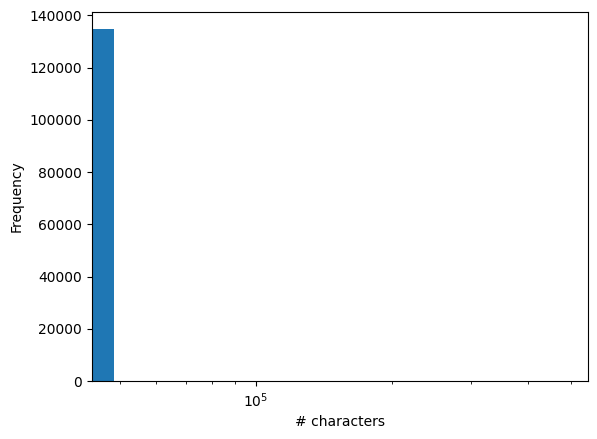

```python
import matplotlib.pyplot as plt
plt.hist(res.sumChars.to_numpy())
plt.xlabel("# characters")
plt.ylabel("Frequency")
plt.xscale("log")
```

```python
!curl https://2.bp.blogspot.com/-eGskF3n8_Ag/XE7F3P_de2I/AAAAAAAAHU8/WJw0un2nHqMGA8cFVtv_yFfpBVQJSYyVACK4BGAYYCw/s1600/Icon-Reddit.png > reddit.png
from wordcloud import WordCloud, ImageColorGenerator
from PIL import Image

mask = np.array(Image.open("reddit.png"))
text = " ".join([i for i in kdf.selftext.to_numpy() if len(i) > 0 and i != "[removed]" and i!="[deleted]"])
```

```
  % Total    % Received % Xferd  Average Speed   Time    Time     Time  Current
                                 Dload  Upload   Total   Spent    Left  Speed
100 76004  100 76004    0     0   678k      0 --:--:-- --:--:-- --:--:--  680k
```

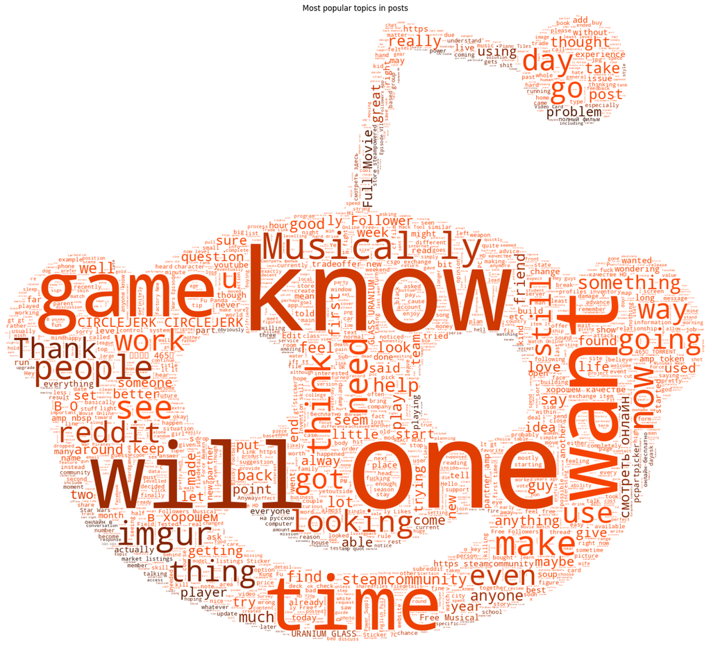

```python
text = " ".join([i for i in kdf.selftext.to_numpy() if len(i) > 0 and i != "[removed]" and i!="[deleted]"])
wordcloud = WordCloud(max_words=5000, mask=~mask[:,:,0], background_color="white", mode="RGBA").generate(text)
# create coloring from image
image_colors = ImageColorGenerator(mask)
plt.figure(figsize=(20,20))
plt.imshow(wordcloud.recolor(color_func=image_colors), interpolation="bilinear")
plt.title("Most popular topics in posts")
plt.axis("off");
```

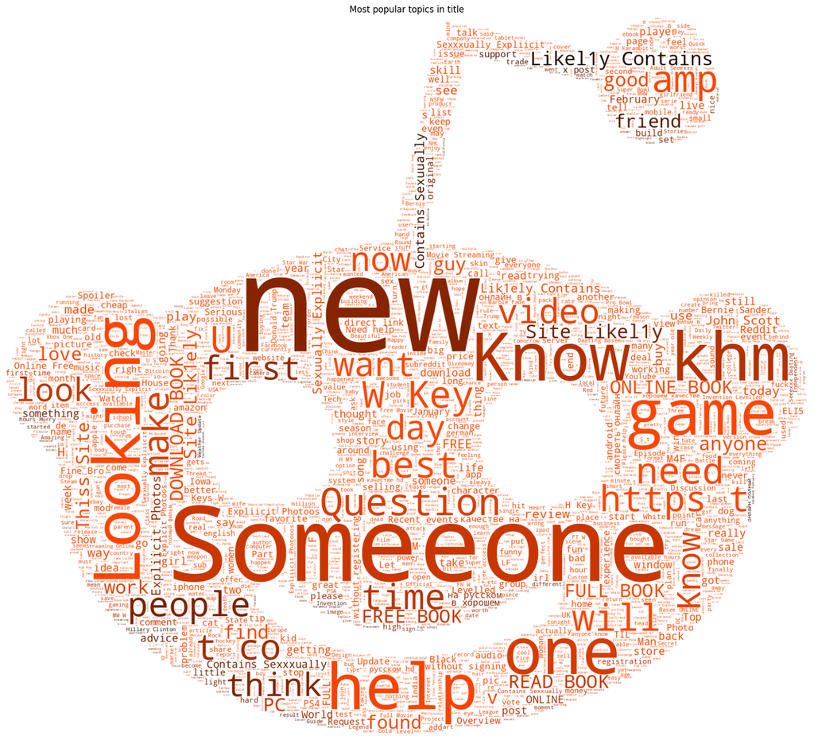

```python
text = " ".join([i for i in kdf.title.to_numpy() if len(i) > 0 and i != "[removed]" and i!="[deleted]"])
wordcloud = WordCloud(max_words=5000, mask=~mask[:,:,0], background_color="white", mode="RGBA").generate(text)
# create coloring from image
image_colors = ImageColorGenerator(mask)
plt.figure(figsize=(20,20))
plt.imshow(wordcloud.recolor(color_func=image_colors), interpolation="bilinear")
plt.title("Most popular topics in title")
plt.axis("off");
```

Assignment question

Choose a subreddit you like and build a worldcloud using Koalas. Feel free to change the mask or the colors...

Answer:

```
  % Total    % Received % Xferd  Average Speed   Time    Time     Time  Current
                                 Dload  Upload   Total   Spent    Left  Speed
100 89067  100 89067    0     0   241k      0 --:--:-- --:--:-- --:--:--  242k
```

[figure not shown]

```python
!curl https://images.ctfassets.net/4cd45et68cgf/Rx83JoRDMkYNlMC9MKzcB/2b14d5a59fc3937afd3f03191e19502d/Netflix-Symbol.png > netflix.png

from wordcloud import WordCloud, ImageColorGenerator
from PIL import Image

mask = np.array(Image.open("netflix.png"))
text = " ".join([i for i in kdf.selftext.to_numpy() if len(i) > 0 and i != "[removed]" and i!="[deleted]"])
wordcloud = WordCloud(max_words=3000, mask=~mask[:,:,0], background_color="black", mode="RGBA").generate(text)

image_colors = ImageColorGenerator(mask)
plt.figure(figsize=(20,20))
plt.imshow(wordcloud.recolor(color_func=image_colors), interpolation="bilinear")
plt.title("Most popular topics in title")
plt.axis("off");
```

# **(A.4) (Homogeneidad I)**

```python
# Probamos distintos tipos de elementos (int, str, double, dic, list)
rdd = sc.parallelize([1, "hola", 3.5, [1, 2, 3]], None)
```

[output not shown]

```python
def homogeneo(rdd):
    types = rdd.map(type).distinct().collect()
    if len(types) == 1:
        print("Todos los elementos son del mismo tipo")
    else:
        print("El RDD contiene elementos de diferentes tipos")
```

```python
homogeneo(rdd)
```

```
El RDD contiene elementos de diferentes tipos
```

# **(A.6) (SparkSQL vs RDD)**

```python
from time import time
import matplotlib.pyplot as plt
from pyspark.sql import SparkSession

spark = SparkSession.builder.appName("CalculoMedia").getOrCreate()

# Crear un DataFrame de ejemplo
data = [(1,), (2,), (3,), (4,), (5,), (6,), (7,), (8,), (9,), (10,)]
df = spark.createDataFrame(data, ["valor"])

# Obtener la columna "valor" como RDD
rdd = df.select("valor").rdd.map(lambda row: row[0])

# Calcular la media usando RDD (map y reduce)
start_rdd = time()
mean_rdd = rdd.reduce(lambda x, y: x + y) / rdd.count()
time_rdd = time() - start_rdd
print("Media (RDD - map y reduce):", mean_rdd, "- Tiempo:", time_rdd, "segundos")

# Calcular la media usando SparkSQL
start_sql = time()
mean_sql = df.agg({"valor": "avg"}).first()[0]
time_sql = time() - start_sql
print("Media (SparkSQL):", mean_sql, "- Tiempo:", time_sql, "segundos")
```

```
Media (RDD - map y reduce): 5.5 - Tiempo: 5.350532293319702 segundos
Media (SparkSQL): 5.5 - Tiempo: 2.264106512069702 segundos
```

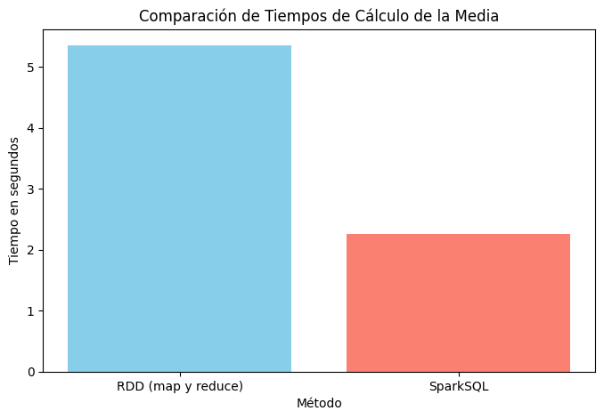

```python
# Crear gráfica de tiempos
methods = ['RDD (map y reduce)', 'SparkSQL']
times = [time_rdd, time_sql]

plt.figure(figsize=(8, 5))
plt.bar(methods, times, color=['skyblue', 'salmon'])
plt.xlabel("Método")
plt.ylabel("Tiempo en segundos")
plt.title("Comparación de Tiempos de Cálculo de la Media")
plt.show()
```